Single Cell Downstream Analysis

Импортируем нужные библиотеки

```r
library(Seurat)
library(ggplot2)
library(dplyr)
```

Загрузим файл с нейронами, в котором судя по файлу metadata_FACS.csv точно более 2 подгрупп клеток.

```r
Brain_Neurons <- read.csv("C:\\Users\\asus\\Documents\\FACS\\FACS\\Brain_Neurons-counts.csv")
head(Brain_Neurons)
```

[output not shown]

[output cut: 280 more lines]

[output not shown]

Уберем пропуски и создадим seurat-объект

```r
Brain_Neurons_clean <- na.omit(Brain_Neurons)
seurat_BN <- CreateSeuratObject(counts = Brain_Neurons_clean, project = "BN")
```

Попробуем посчитать процентное содержание митоходриальных генов

```r
seurat_BN[["percent.mt"]] <- PercentageFeatureSet(seurat_BN, pattern = "(?i)^Mt")
```

Судя по всему, конкретно эта часть кода не работает, причем я не понимаю почему. Я игнорирую регистр, посмотрел наличие митохондриальных генов в данных, а процент все равно всюду 0, это можно увидеть вдальнейшем на графике:

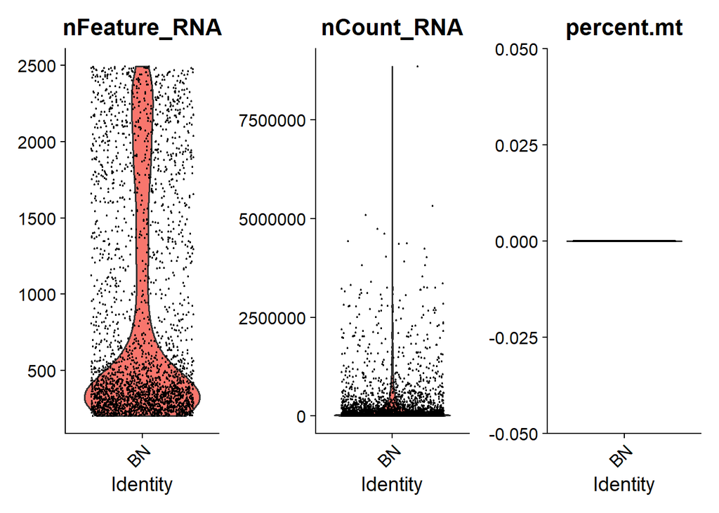

```r
VlnPlot(seurat_BN_filtered, features = c("nFeature_RNA", "nCount_RNA", "percent.mt"), ncol = 3)
```

Проведем отчистку от выбросов и заодно посмотрим, какая часть данных удалена

```r
seurat_BN_filtered <- subset(seurat_BN, subset = nFeature_RNA > 200 & nFeature_RNA < 2500 & percent.mt < 5)
cat("Было:", ncol(seurat_BN), "клеток\n")
```

```
## Было: 5800 клеток
```

```r
cat("Стало:", ncol(seurat_BN_filtered), "клеток\n")
```

```
## Стало: 2796 клеток
```

```r
cat("Отфильтровано:", ncol(seurat_BN) - ncol(seurat_BN_filtered), "клеток\n")
```

```
## Отфильтровано: 3004 клеток
```

Половина данных была удалена - возможно, данные правда оказались очень грязными, либо же стоит поэкспериментировать с параметром nFeature_RNA. Нормализуем данные

```r
seurat_BN_normalized <- NormalizeData(seurat_BN_filtered)
```

```
## Normalizing layer: counts
```

Проведем кластеризацию, затем визуализируем полученное разбиение

```r
seurat_BN_normalized <- FindVariableFeatures(seurat_BN_normalized, selection.method = "vst")
```

```
## Finding variable features for layer counts
```

```r
seurat_BN_normalized <- ScaleData(seurat_BN_normalized)
seurat_BN_normalized <- RunPCA(seurat_BN_normalized, features = VariableFeatures(object = seurat_BN_normalized))
```

```
## PC_ 1
## Positive:  4747, 6763, 11331, 6772, 6773, 6732, 12417, 6784, 6782, 23148
##     17682, 6766, 6739, 4160, 6745, 6734, 18471, 13426, 6810, 6808
##     6806, 6765, 3708, 16177, 6731, 5187, 6777, 21372, 6085, 2474
## Negative:  2963, 4213, 12267, 21121, 17558, 8430, 9772, 21690, 16423, 7093
##     12233, 5052, 12265, 5210, 6525, 9935, 10829, 13431, 15798, 19340
##     15819, 11850, 3796, 9930, 2980, 927, 8210, 20864, 11087, 21706
## PC_ 2
## Positive:  3319, 19136, 9773, 3703, 14507, 3323, 5148, 16604, 19135, 8352
##     5051, 8364, 5548, 2345, 17452, 14503, 2353, 2696, 21689, 13349
##     7312, 12590, 21595, 12150, 3919, 7854, 14222, 6873, 18832, 5383
## Negative:  12233, 5052, 13431, 12265, 15819, 2980, 7093, 17376, 21404, 21706
##     20998, 11850, 7198, 16695, 21587, 20945, 3796, 9772, 11243, 16336
##     18907, 18756, 8210, 4619, 17983, 6604, 19340, 21690, 927, 2506
## PC_ 3
## Positive:  11052, 16705, 12154, 12153, 16374, 5674, 18662, 11111, 11847, 10548
##     7929, 10370, 20762, 3162, 14453, 14422, 5837, 18822, 3846, 19312
##     15984, 17407, 21754, 6077, 19294, 16218, 21034, 22715, 10663, 22722
## Negative:  2963, 16695, 12233, 12417, 5052, 9701, 17376, 5210, 13431, 15819
##     21706, 9772, 16658, 10829, 5492, 21404, 11850, 7198, 13426, 21587
##     20998, 15798, 20945, 927, 16423, 12350, 16336, 7093, 11243, 6604
## PC_ 4
## Positive:  12522, 19470, 4917, 16569, 20364, 19571, 7030, 3322, 19580, 18411
##     20191, 6460, 18587, 19561, 3772, 13943, 2097, 3771, 7110, 20954
##     13661, 9988, 14030, 17271, 9645, 13945, 14093, 6244, 19173, 8128
## Negative:  8430, 2981, 8352, 14507, 4213, 12590, 5562, 5051, 17056, 8364
##     19136, 21689, 12154, 13349, 11052, 12153, 16705, 2345, 16423, 19232
##     19135, 16374, 3319, 3919, 5674, 19382, 5148, 7854, 8210, 2353
## PC_ 5
## Positive:  11052, 16374, 12154, 16705, 12153, 5674, 18662, 15984, 6077, 10370
##     19312, 16218, 8430, 11847, 14611, 9692, 19294, 12265, 10663, 2047
##     21690, 8210, 3840, 5111, 21034, 22715, 12100, 3846, 21937, 9932
## Negative:  13830, 20448, 2363, 21331, 13808, 8355, 14444, 16691, 22709, 18354
##     16263, 17719, 7848, 17951, 3213, 15983, 4375, 18836, 11859, 12426
##     16369, 6526, 9986, 17407, 22526, 10724, 12135, 13780, 9915, 13410
```

```r
seurat_BN_normalized <- FindNeighbors(seurat_BN_normalized, dims = 1:10)
seurat_BN_normalized <- FindClusters(seurat_BN_normalized, resolution = 0.5)
```

```
## Modularity Optimizer version 1.3.0 by Ludo Waltman and Nees Jan van Eck
##
## Number of nodes: 2796
## Number of edges: 91493
##
## Running Louvain algorithm...
## Maximum modularity in 10 random starts: 0.8763
## Number of communities: 11
## Elapsed time: 1 seconds
```

```r
seurat_BN_umap <- RunUMAP(seurat_BN_normalized, dims = 1:10)
```

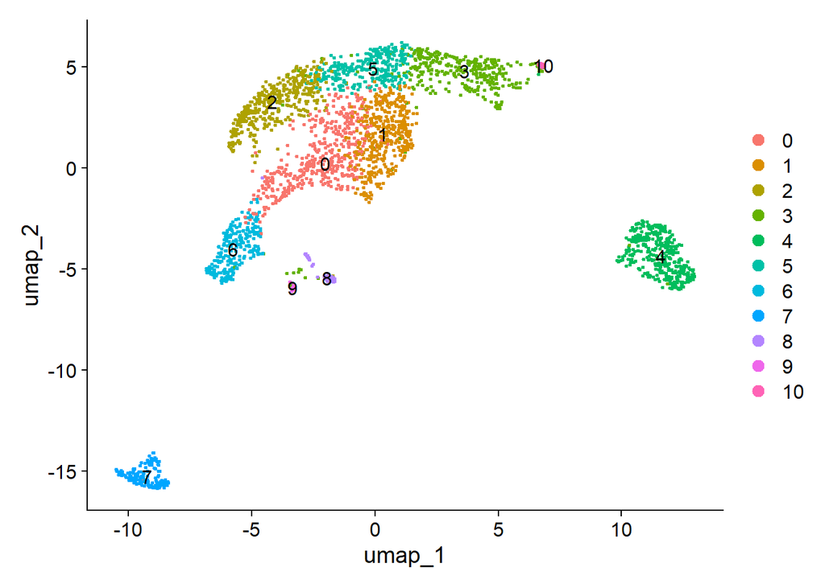

```r
DimPlot(seurat_BN_umap, reduction = "umap", label=TRUE)
```

**Вывод:** за исключением кластеров 4 и 7, остальные клетки не так хорошо разделимы в целом. Тем не менее, разделение присутствует, что мы и ожидали увидеть. Визуализируем теперь гендерное разбиение

```r
seurat_BN_umap$gender <- ifelse(grepl("_M\\.", colnames(seurat_BN_umap)), "Male", "Female")
table(seurat_BN_umap$gender)
```

```
##
## Female   Male
##   1219   1577
```

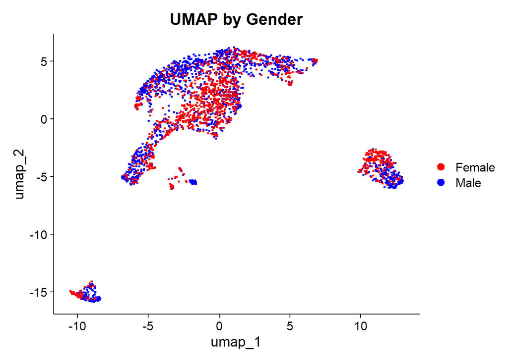

```r
DimPlot(seurat_BN_umap,
        reduction = "umap",
        group.by = "gender",
        cols = c("Male" = "blue", "Female" = "red")) +
  ggtitle("UMAP by Gender")
```

**Вывод:** в целом в каждом “кластере” можно увидеть места, в которых предпочтительно сосредоточены клетки каждого гендера. Особеено виден установленный кластер 8, который почти полностью состоит из мужских клеток. Попробуем более точно изобразить соотношение клеток каждого гендера в каждом выделенном кластере:

```r
gender_cluster_table <- table(seurat_BN_umap$seurat_clusters,
                             seurat_BN_umap$gender)
cluster_gender_df <- as.data.frame(gender_cluster_table)
colnames(cluster_gender_df) <- c("Cluster", "Gender", "Count")
cluster_gender_df <- cluster_gender_df %>%
  group_by(Cluster) %>%
  mutate(Percentage = Count / sum(Count) * 100) %>%
  ungroup()
```

C тем, чтобы график ниже был более красивым и читабельным, помог Deepseek.

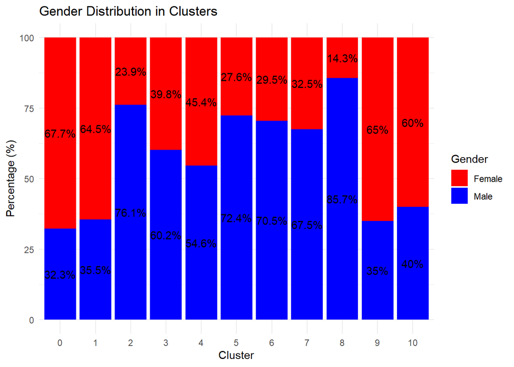

```r
ggplot(cluster_gender_df, aes(x = Cluster, y = Percentage, fill = Gender)) +
  geom_bar(stat = "identity") +
  geom_text(aes(label = paste0(round(Percentage, 1), "%")),
            position = position_stack(vjust = 0.5),
            color = "black") +
  scale_fill_manual(values = c("Male" = "blue", "Female" = "red")) +
  labs(title = "Gender Distribution in Clusters",
       x = "Cluster",
       y = "Percentage (%)") +
  theme_minimal()
```

**Вывод:** как было видно по верхнему графику, кластер 8 действительно предпочтительно состоит из мужских клеток, также выделяется кластер 2, в котором мужских клеток в 3 раза больше женских. В обратную сторону имеются кластеры 0, 1 и 9, количество женских клеток которых примерно в 2 раза больше мужских. Отойдем от гендерного разбиения и попробуем разделить два кластера более детально - по экспрессируемым генам.

```r
cluster_counts <- table(seurat_BN_umap$seurat_clusters)
print("Количество клеток в кластерах:")
```

```
## [1] "Количество клеток в кластерах:"
```

```r
print(cluster_counts)
```

```
##
##   0   1   2   3   4   5   6   7   8   9  10
## 439 422 402 372 370 297 251 154  49  20  20
```

```r
cluster2 <- "2"
cluster4 <- "4"
seurat_subset <- subset(seurat_BN_umap,
                       subset = seurat_clusters %in% c(cluster2, cluster4))
Idents(seurat_subset) <- "seurat_clusters"
de_genes <- FindMarkers(seurat_subset,
                       ident.1 = cluster2,
                       ident.2 = cluster4,
                       min.pct = 0.25,
                       logfc.threshold = 0.25,
                       only.pos = FALSE)

top_genes <- rownames(head(de_genes, 10))
print("Топ-10 дифференциально экспрессированных генов:")
```

```
## [1] "Топ-10 дифференциально экспрессированных генов:"
```

```r
print(top_genes)
```

```
##  [1] "7885"  "5071"  "11052" "12154" "16705" "12153" "19245" "19425" "3905"  "7113"
```

Визуализируем Heatmap:

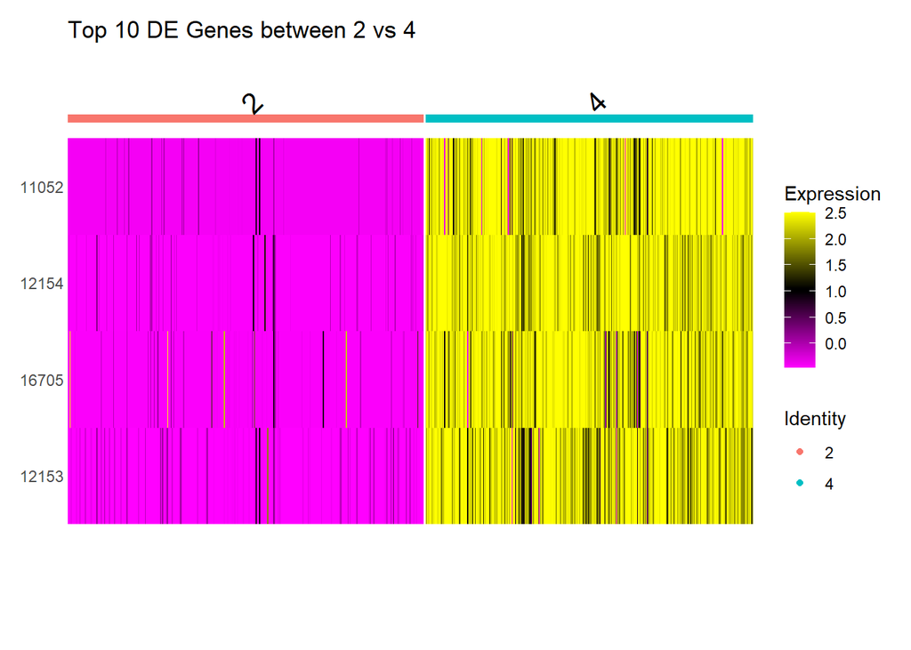

```r
DoHeatmap(seurat_subset,
          features = top_genes,
          group.by = "seurat_clusters",
          label = TRUE) +
  ggtitle(paste("Top 10 DE Genes between", cluster2, "vs", cluster4))
```

**Вывод:** По heatmap можно видеть, что эти два кластера действительно практически полностью разделяются по этим генам. (Вторая неустраненная ошибка - непонятно, почему только эти 4 гена показаны, а остальные 6 - нет. При этом если попытаться визуализировать только один из непредставленных генов - выйдет ошибка что такого гена нет, хотя ранее мы как-то их нашли.)

**Общий вывод по задаче:** задача довольно трудоемкая, особенно с учетом полного погружения в язык R. По началу было довольно сложно разобраться в том, что за что отвечает в данных, как вообще проводить Quality Control. С туториалом стало намного проще, а с учетом того, что графики строятся довольно схожим с питоном образом, дела пошли в гору. Самый интересный пункт - 4, но наверное я предвзят, потому что мне всегда нравится кластеризация - как будто какая-то магия происходит, когда модель смотрит на какие-то конкретные признаки и суммарно так хорошо разделяет данные (как с кластерами 4 и 7). Большая часть того, что я изучил в ходе решения этой задачи связана по большей части с языком R, основной интересный пункт из биологии - для клеток разных гендеров нужно разное количество генов (а иногда и разные гены в принципе). Удивительно, что речь идет о нейронах - клетках, казалось бы далеких от специализации в гендерном плане. Это может оказаться очень важным например при синтезе лекарств - в случае разных полов можно ожидать разный ответ на одни и те же вещества.